# Modeling

Marcus Needham

2024-10-24

```r
# Define threshold for downtime to distinguish between minor and major breakdowns
threshold <- 60  # Breakdowns longer than 60 minutes are considered major

# Create a single target variable 'major_breakdown'
rf_data$major_breakdown <- ifelse(rf_data$ACTUAL_WORK_IN_MINUTES > threshold, 1, 0)

# Randomly sample 100,000 rows if necessary due to memory constraints
set.seed(123)
sampled_data <- rf_data[sample(nrow(rf_data), 100000), ]

# Convert categorical variables to factors
sampled_data$MAINTENANCE_ACTIVITY_TYPE <- as.factor(sampled_data$MAINTENANCE_ACTIVITY_TYPE)

# Remove rows with any missing values
sampled_data <- sampled_data[complete.cases(sampled_data), ]

# Confirm that there are no missing values left
colSums(is.na(sampled_data))
```

```
##             PRODUCTION_LOCATION            EXECUTION_START_DATE
##                               0                               0
##           EXECUTION_FINISH_DATE               ACTUAL_START_TIME
##                               0                               0
##              ACTUAL_FINISH_TIME          ACTUAL_WORK_IN_MINUTES
##                               0                               0
##                MAINTENANCE_PLAN                MAINTENANCE_ITEM
##                               0                               0
##       MAINTENANCE_ACTIVITY_TYPE               ORDER_DESCRIPTION
##                               0                               0
##    MAINTENANCE_TYPE_DESCRIPTION                  FUNCTIONAL_LOC
##                               0                               0
## FUNCTIONAL_AREA_NODE_1_MODIFIED FUNCTIONAL_AREA_NODE_2_MODIFIED
##                               0                               0
## FUNCTIONAL_AREA_NODE_3_MODIFIED FUNCTIONAL_AREA_NODE_4_MODIFIED
##                               0                               0
## FUNCTIONAL_AREA_NODE_5_MODIFIED                    EQUIPMENT_ID
##                               0                               0
##                  EQUIPMENT_DESC                  EQUIP_CAT_DESC
##                               0                               0
##             EQUIP_START_UP_DATE                EQUIP_VALID_FROM
##                               0                               0
##                  EQUIP_VALID_TO                 major_breakdown
##                               0                               0
```

```r
# Split the data into training and testing sets
set.seed(123)  # For reproducibility
train_index <- sample(1:nrow(sampled_data), 0.8 * nrow(sampled_data))
train_data <- sampled_data[train_index, ]
test_data <- sampled_data[-train_index, ]
```

```r
# Convert the target variable to a factor for classification
train_data$major_breakdown <- as.factor(train_data$major_breakdown)
test_data$major_breakdown <- as.factor(test_data$major_breakdown)

# Build the Random Forest model
library(randomForest)
rf_model <- randomForest(
  major_breakdown ~ . - ACTUAL_WORK_IN_MINUTES,  # Exclude the original ACTUAL_WORK_IN_MINUTES column
  data = train_data,
  ntree = 100,  # Adjust as needed
  mtry = 3,     # Adjust based on the number of features
  importance = TRUE
)

# Print the model summary
print(rf_model)
```

```
##
## Call:
##  randomForest(formula = major_breakdown ~ . - ACTUAL_WORK_IN_MINUTES,      data = train_data, ntree = 100, mtry = 3, importance = TRUE)
##                Type of random forest: classification
##                      Number of trees: 100
## No. of variables tried at each split: 3
##
##         OOB estimate of  error rate: 11.47%
## Confusion matrix:
##       0    1 class.error
## 0 33876  779  0.02247872
## 1  4055 3434  0.54146081
```

```r
# Predict on the test set
rf_predictions <- predict(rf_model, test_data)

# Confusion matrix
library(caret)
confusionMatrix(rf_predictions, test_data$major_breakdown)
```

```
## Confusion Matrix and Statistics
##
##           Reference
## Prediction    0    1
##          0 8354 1632
##          1  226  324
##
##                Accuracy : 0.8237
##                  95% CI : (0.8162, 0.8309)
##     No Information Rate : 0.8144
##     P-Value [Acc > NIR] : 0.007018
##
##                   Kappa : 0.1928
##
##  Mcnemar's Test P-Value : < 2.2e-16
##
##             Sensitivity : 0.9737
##             Specificity : 0.1656
##          Pos Pred Value : 0.8366
##          Neg Pred Value : 0.5891
##              Prevalence : 0.8144
##          Detection Rate : 0.7929
##    Detection Prevalence : 0.9478
##       Balanced Accuracy : 0.5697
##
##        'Positive' Class : 0
##
```

```r
# Calculate accuracy
accuracy <- mean(rf_predictions == test_data$major_breakdown)
print(paste("Test Accuracy:", accuracy))
```

```
## [1] "Test Accuracy: 0.823652239939256"
```

```r
# View and plot feature importance
importance <- importance(rf_model)
print(importance)
```

```
##                                         0         1 MeanDecreaseAccuracy
## PRODUCTION_LOCATION              7.642747  6.526647             9.164362
## EXECUTION_START_DATE            24.843110 10.632953            27.483672
## EXECUTION_FINISH_DATE           25.806561 11.964823            27.899640
## ACTUAL_START_TIME               15.251604 19.397577            20.703056
## ACTUAL_FINISH_TIME              20.708624 18.395684            25.303575
## MAINTENANCE_PLAN                20.617307 20.282136            27.329086
## MAINTENANCE_ITEM                21.079972 14.637219            23.899121
## MAINTENANCE_ACTIVITY_TYPE        4.178151  8.908784             9.028124
## ORDER_DESCRIPTION               26.959483 25.255616            32.843920
## MAINTENANCE_TYPE_DESCRIPTION     3.965772 11.018398            10.518207
## FUNCTIONAL_LOC                  14.079310 12.664798            18.686936
## FUNCTIONAL_AREA_NODE_1_MODIFIED  9.532311  6.768382            10.622450
## FUNCTIONAL_AREA_NODE_2_MODIFIED 10.189154 14.746120            16.266951
## FUNCTIONAL_AREA_NODE_3_MODIFIED 15.847927 14.418280            18.085733
## FUNCTIONAL_AREA_NODE_4_MODIFIED 21.878588 23.035298            25.381076
## FUNCTIONAL_AREA_NODE_5_MODIFIED -2.866417  6.057533             1.260090
## EQUIPMENT_ID                    16.167001 11.063794            19.034491
## EQUIPMENT_DESC                   9.339636  9.057252            10.684440
## EQUIP_CAT_DESC                   4.062186  3.374962             5.028552
## EQUIP_START_UP_DATE              5.616274  3.993411             6.684533
## EQUIP_VALID_FROM                 6.485205  8.405287             8.866861
## EQUIP_VALID_TO                   4.646422  3.679000             5.844210
##                                 MeanDecreaseGini
## PRODUCTION_LOCATION                    173.01384
## EXECUTION_START_DATE                   750.01125
## EXECUTION_FINISH_DATE                  782.98592
## ACTUAL_START_TIME                      358.19713
## ACTUAL_FINISH_TIME                     358.03788
## MAINTENANCE_PLAN                       876.83474
## MAINTENANCE_ITEM                       923.17251
## MAINTENANCE_ACTIVITY_TYPE               98.83655
## ORDER_DESCRIPTION                      704.46908
## MAINTENANCE_TYPE_DESCRIPTION           173.25361
## FUNCTIONAL_LOC                         568.38402
## FUNCTIONAL_AREA_NODE_1_MODIFIED        109.09392
## FUNCTIONAL_AREA_NODE_2_MODIFIED        280.04598
## FUNCTIONAL_AREA_NODE_3_MODIFIED        308.38801
## FUNCTIONAL_AREA_NODE_4_MODIFIED        348.90452
## FUNCTIONAL_AREA_NODE_5_MODIFIED         10.29334
## EQUIPMENT_ID                           619.04112
## EQUIPMENT_DESC                         163.80519
## EQUIP_CAT_DESC                          22.77641
## EQUIP_START_UP_DATE                     46.22789
## EQUIP_VALID_FROM                        79.05883
## EQUIP_VALID_TO                          18.85822
```

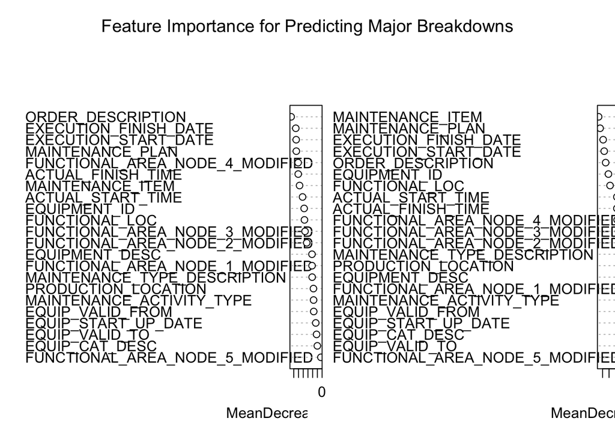

```r
# Plot the feature importance
varImpPlot(rf_model, main = "Feature Importance for Predicting Major Breakdowns")
```

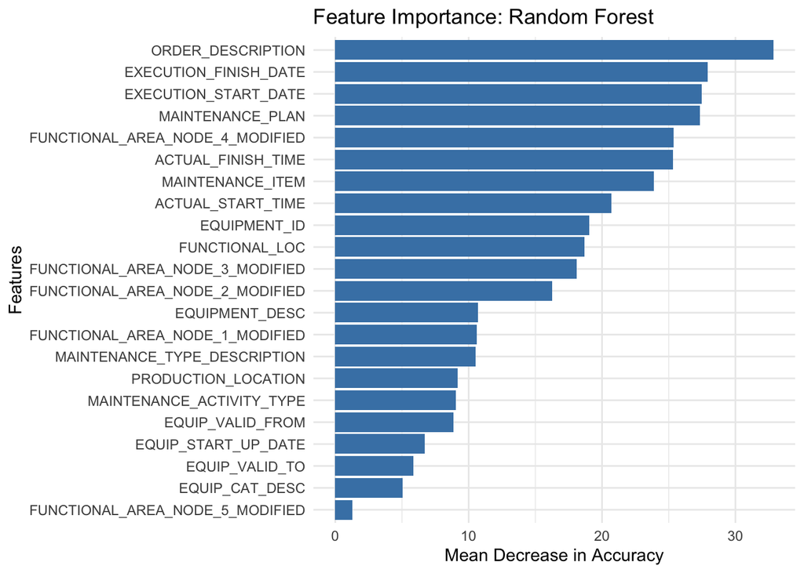

```r
# Extract feature importance and convert it into a data frame
importance_df <- data.frame(
  Feature = rownames(importance),
  MeanDecreaseAccuracy = importance[, "MeanDecreaseAccuracy"],
  MeanDecreaseGini = importance[, "MeanDecreaseGini"]
)

# Sort by MeanDecreaseAccuracy for better visualization
importance_df <- importance_df %>% arrange(desc(MeanDecreaseAccuracy))

# Load ggplot2 library
library(ggplot2)

# Plot the feature importance based on MeanDecreaseAccuracy
ggplot(importance_df, aes(x = reorder(Feature, MeanDecreaseAccuracy), y = MeanDecreaseAccuracy)) +
  geom_bar(stat = "identity", fill = "steelblue") +
  coord_flip() +  # Flip coordinates for horizontal bars
  labs(
    title = "Feature Importance: Random Forest",
    x = "Features",
    y = "Mean Decrease in Accuracy"
  ) +
  theme_minimal()
```

This graph displays the feature importance from a Random Forest model used to predict machine breakdowns. The importance is measured by the “Mean Decrease in Accuracy,” which indicates how much the model’s predictive accuracy would decrease if the feature were removed.

Key insights include:

Order Description and Execution Dates (Start/Finish) are the most influential predictors, likely capturing detailed contextual or operational information critical to breakdown patterns. Maintenance Plan and Maintenance Items also rank high, highlighting the relevance of maintenance scheduling and specific interventions. Features like Functional Location and Equipment ID play a moderate role, suggesting spatial or machine-specific factors contribute to breakdown risks. These results emphasize the importance of operational and maintenance data in predicting and mitigating machine breakdowns.

## Major vs Minor Breakdowns

```r
# Define a variable for breakdown type (Minor or Major)
threshold <- 60  # Define the threshold for major breakdowns
rf_data$breakdown_type <- ifelse(rf_data$ACTUAL_WORK_IN_MINUTES > threshold, "Major", "Minor")

# Create a summary table of breakdown counts
breakdown_counts <- table(rf_data$breakdown_type)

# Print the summary table
print(breakdown_counts)
```

```
##
##  Major  Minor
##  92754 199041
```

```r
# Add proportions to the table
breakdown_proportions <- prop.table(breakdown_counts) * 100

# Print proportions
print(breakdown_proportions)
```

```
##
##    Major    Minor
## 31.78738 68.21262
```